# Beer Project

Daniel Chang

2022-10-19

## Load libraries and datasets

Loading libraries and datasets for project use

## Exploratory Data Analysis(EDA)

In the Exploratory Data Analysis section, we will be cleaning and exploring the dataset to address any questions that we may have.

### 1. How many breweries are present in each state?

From the bar plot above, we find that Colorado has the most number of breweries in its state with California being the second.

The code below counts the number of breweries in each state and arrange them in descending order. After that, we create a bar chart that plots our findings.

```r
totalBrew %>% group_by(State) %>% count(State) %>% arrange(desc(n))
```

```
## # A tibble: 51 × 2
## # Groups:   State [51]
##    State     n
##    <chr> <int>
##  1 " CO"    47
##  2 " CA"    39
##  3 " MI"    32
##  4 " OR"    29
##  5 " TX"    28
##  6 " PA"    25
##  7 " MA"    23
##  8 " WA"    23
##  9 " IN"    22
## 10 " WI"    20
## # … with 41 more rows
## # ℹ Use `print(n = ...)` to see more rows
```

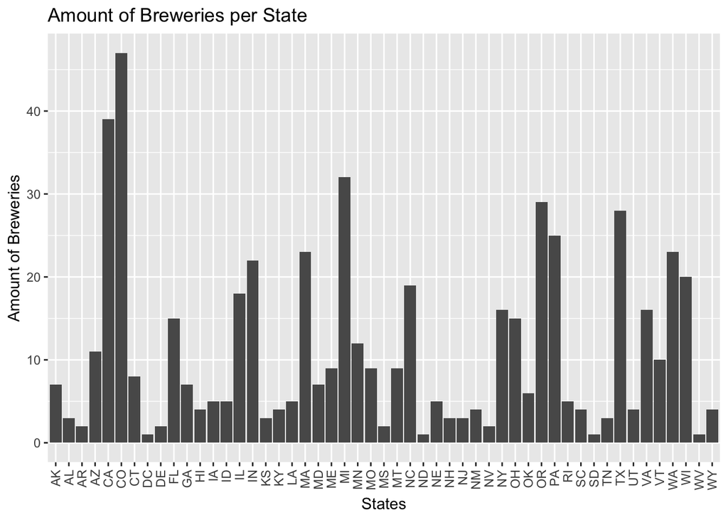

```r
ggplot(totalBrew, aes(x = State), fill = State) + geom_bar() +
  labs(title ="Amount of Breweries per State", x = "States", y = "Amount of Breweries") +
  theme(axis.text.x = element_text(angle = 90, vjust = 0.5, hjust=1))
```

### 2. Merge beer data with the breweries data. Print the first 6 observations

There are total of 2410 rows and 10 columns after merging the two datasets.

The code below merges our 2 dataset together and prints out the first and last 6 rows.

```r
mergedB = merge(totalBeer, totalBrew, by.x = "Brewery_id", by.y = "Brew_ID")
dim(mergedB)
```

```
## [1] 2410   10
```

```r
#Looking at the first 6 observations and returning them
head(mergedB, n=6)
```

```
##   Brewery_id        Name.x Beer_ID   ABV IBU
## 1          1  Get Together    2692 0.045  50
## 2          1 Maggie's Leap    2691 0.049  26
## 3          1    Wall's End    2690 0.048  19
## 4          1       Pumpion    2689 0.060  38
## 5          1    Stronghold    2688 0.060  25
## 6          1   Parapet ESB    2687 0.056  47
##                                 Style Ounces             Name.y        City
## 1                        American IPA     16 NorthGate Brewing  Minneapolis
## 2                  Milk / Sweet Stout     16 NorthGate Brewing  Minneapolis
## 3                   English Brown Ale     16 NorthGate Brewing  Minneapolis
## 4                         Pumpkin Ale     16 NorthGate Brewing  Minneapolis
## 5                     American Porter     16 NorthGate Brewing  Minneapolis
## 6 Extra Special / Strong Bitter (ESB)     16 NorthGate Brewing  Minneapolis
##   State
## 1    MN
## 2    MN
## 3    MN
## 4    MN
## 5    MN
## 6    MN
```

```r
#This will give us the last 6th  observations and returning them
tail(mergedB, n = 6)
```

```
##      Brewery_id                    Name.x Beer_ID   ABV IBU
## 2405        556             Pilsner Ukiah      98 0.055  NA
## 2406        557  Heinnieweisse Weissebier      52 0.049  NA
## 2407        557           Snapperhead IPA      51 0.068  NA
## 2408        557         Moo Thunder Stout      50 0.049  NA
## 2409        557         Porkslap Pale Ale      49 0.043  NA
## 2410        558 Urban Wilderness Pale Ale      30 0.049  NA
##                        Style Ounces                        Name.y          City
## 2405         German Pilsener     12         Ukiah Brewing Company         Ukiah
## 2406              Hefeweizen     12       Butternuts Beer and Ale Garrattsville
## 2407            American IPA     12       Butternuts Beer and Ale Garrattsville
## 2408      Milk / Sweet Stout     12       Butternuts Beer and Ale Garrattsville
## 2409 American Pale Ale (APA)     12       Butternuts Beer and Ale Garrattsville
## 2410        English Pale Ale     12 Sleeping Lady Brewing Company     Anchorage
##      State
## 2405    CA
## 2406    NY
## 2407    NY
## 2408    NY
## 2409    NY
## 2410    AK
```

### 3. Address the missing values in each column.

After omitting all of the null values in the merged dataset, we are left with 1405 rows/observations.

The code below omits all null values from all columns.

```r
mergedB = na.omit(mergedB)
dim(mergedB)
```

```
## [1] 1405   10
```

### 4. Compute the median alcohol content (ABV) and international bitterness unit for each state. Plot a bar chart to compare.

The code below creates a new dataframe that summarizes the median ABV and IBU by state. Ater that, we plot our findings on seperate bar charts.

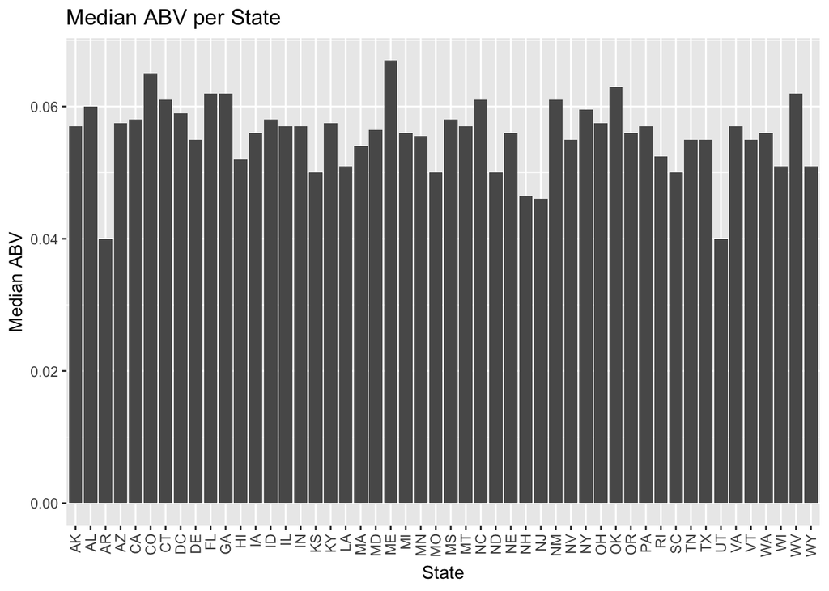

```r
medFrame = mergedB %>% group_by(State) %>% summarise(medianABV = median(ABV), medianIBU = median(IBU))

#plotting by using a bar charts
ggplot(medFrame, aes(x = State, y = medianABV)) + geom_bar(stat = 'identity') + ggtitle("Median ABV per State") + ylab("Median ABV") + theme(axis.text.x = element_text(angle = 90, vjust = 0.5, hjust=1))
```

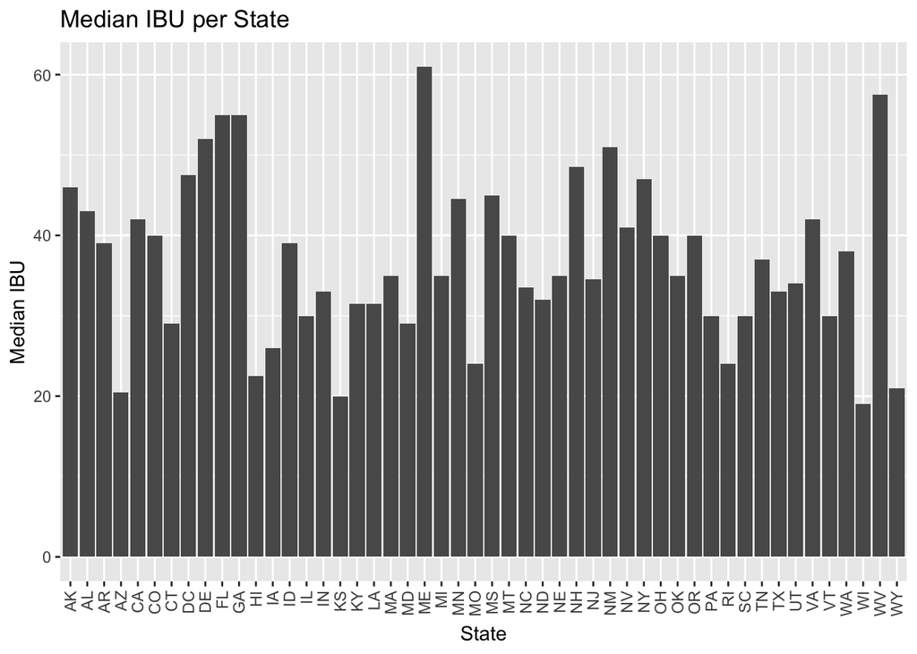

```r
ggplot(medFrame, aes(x = State, y = medianIBU), color = "yellow") + geom_bar(stat = 'identity') + ggtitle("Median IBU per State") + ylab("Median IBU") + theme(axis.text.x = element_text(angle = 90, vjust = 0.5, hjust=1))
```

### 5. Which state has the maximum alcoholic (ABV) beer? Which state has the most bitter (IBU) beer?

The state with the highest median IBU and ABV beer is Maine. When it comes to the highest overall IBU beer, that belongs to Oregon. The highest overall ABV beer belongs to Kentucky.

The code below finds state(s) that has the highest median IBU and ABV, as well as the highest overall.

```r
#arranges columns in descending order to show max #s first
# Gets highest median ABV and IBU
head(arrange(medFrame, desc(medianIBU)), n = 1)
```

```
## # A tibble: 1 × 3
##   State medianABV medianIBU
##   <chr>     <dbl>     <dbl>
## 1 " ME"     0.067        61
```

```r
head(arrange(medFrame, desc(medianABV)), n = 1)
```

```
## # A tibble: 1 × 3
##   State medianABV medianIBU
##   <chr>     <dbl>     <dbl>
## 1 " ME"     0.067        61
```

```r
# Gets highest overall ABV and IBU
head(arrange(mergedB, desc(IBU)), n = 1)
```

```
##   Brewery_id                    Name.x Beer_ID   ABV IBU
## 1        375 Bitter Bitch Imperial IPA     980 0.082 138
##                            Style Ounces                  Name.y    City State
## 1 American Double / Imperial IPA     12 Astoria Brewing Company Astoria    OR
```

```r
head(arrange(mergedB, desc(ABV)), n =1)
```

```
##   Brewery_id         Name.x Beer_ID   ABV IBU              Style Ounces
## 1          2 London Balling    2685 0.125  80 English Barleywine     16
##                      Name.y       City State
## 1 Against the Grain Brewery Louisville    KY
```

### 6.Comment on the summary statistics and distribution of the ABV variable

Looking at the histogram distribution, we find that it is right-skewed. Next, we find that the min ABV is 0.027, 1st quartile in 0.05, median is 0.057, mean is 0.05991, 3rd quartile is 0.068 and max is 0.125.

The code below creates a histogram to plot the distribution of ABV for all the beers and get a summary statistics on the ABV column.

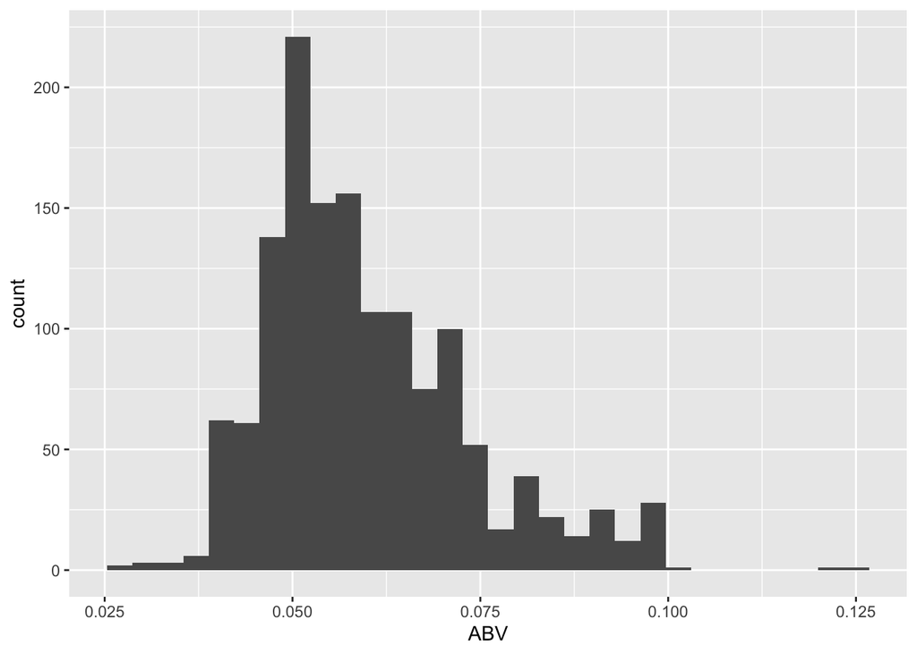

```r
ggplot(mergedB, aes(x = ABV)) + geom_histogram()
```

```r
summary(mergedB$ABV)
```

```
##    Min. 1st Qu.  Median    Mean 3rd Qu.    Max.
## 0.02700 0.05000 0.05700 0.05991 0.06800 0.12500
```

### 7. Is there an apparent relationship between the bitterness of the beer and its alcoholic content?

The relationship appears to be linear and positive but not a strong linear relationship.

The code below plots a scatterplot for us to study the relationship between the bitterness of the beer(IBU) and its alcoholic content(ABV).

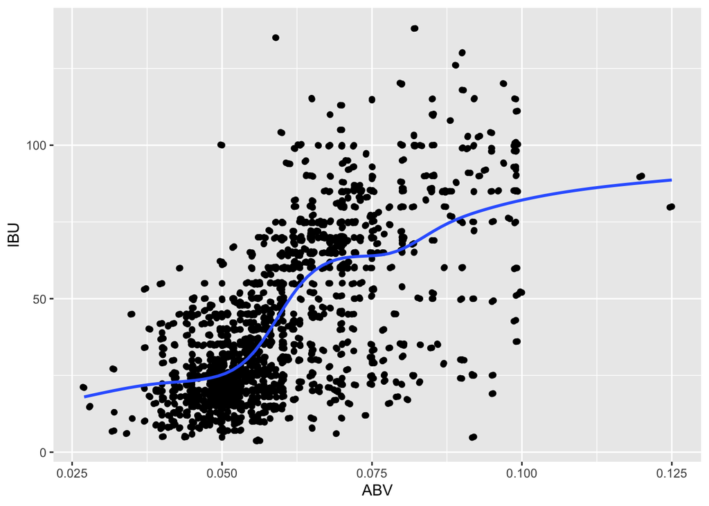

```r
ggplot(mergedB, aes(x = ABV, y = IBU)) + geom_point() + geom_jitter() + geom_smooth(se = FALSE)
```

### 8. Budweiser would also like to investigate the difference with respect to IBU and ABV between IPAs (India Pale Ales) and other types of Ale (any beer with “Ale” in its name other than IPA). You decide to use KNN classification to investigate this relationship. Provide statistical evidence one way or the other. We want to create a confusion matrix that will produce these statistics, as well as, create a predictor that can predict whether a beer is Ale or IPA based on IBU and ABV. The best way to go about this is to create a column called group that speciify whether the beer is “Ale” or “IPA”, rather than its full Style name.

The code below creates a new column that seperate the beer into 2 categories, “Ale” or “IPA” and creates a test and train dataset for us so we can use KNN classifier on. Also, we created a predictor that can predict whether a beer with a specific ABV and IBU will end up as an “Ale” or “IPA”.

```r
#using grepl to find rows with IPA and Ale within Style
mergedBall= mergedB %>% filter(grepl("IPA|Ale", Style))
mergedBall
```

```
##     Brewery_id                                           Name.x Beer_ID   ABV
## 1            1                                     Get Together    2692 0.045
## 2            1                                       Wall's End    2690 0.048
## 3            1                                          Pumpion    2689 0.060
## 4            2                                   Citra Ass Down    2686 0.080
## 5            2                                           A Beer    2683 0.042
## 6            2                                    Flesh Gourd'n    2681 0.066
## 7            2                                         Sho'nuff    2680 0.040
## 8            2                                      Rico Sauvin    2678 0.076
## 9            2                                 Coq de la Marche    2677 0.051
## 10           2                                     Pile of Face    2675 0.060
## 11           2                                   The Brown Note    2674 0.050
## 12           4                                   Habitus (2014)    2668 0.080
## 13           4                                            Solis    2667 0.075
## 14           4                                         Jucundus    2666 0.060
```

[output cut: 2820 more lines]

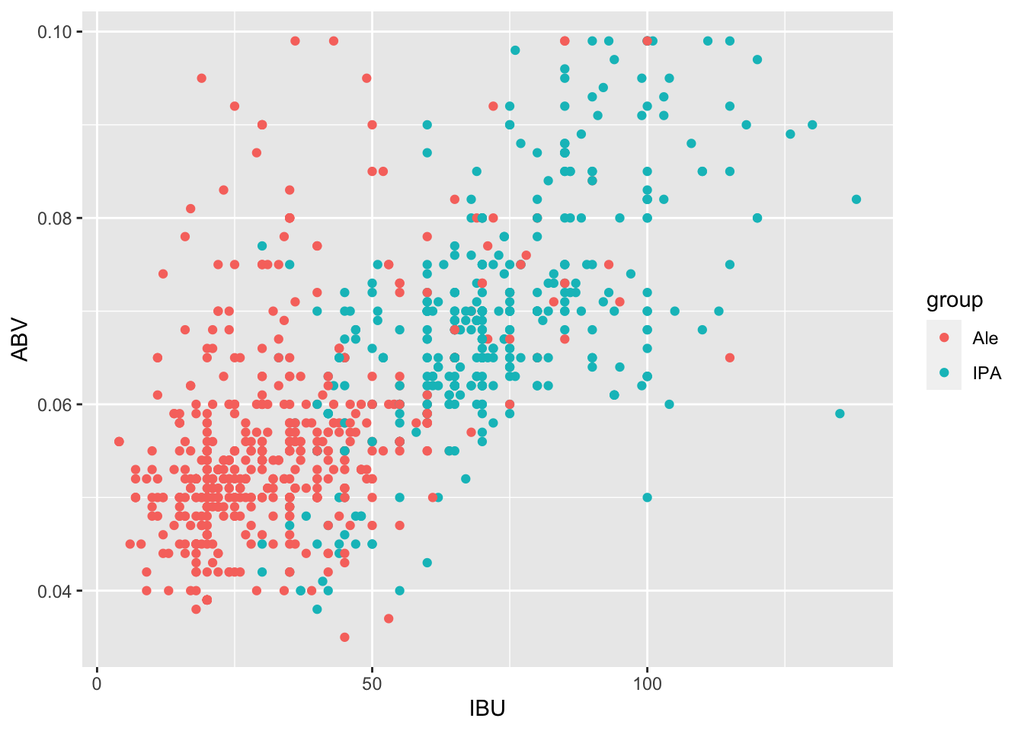

```r
# create new column called group to seperate Ale and IPA without specific name
for (i in 1:length(mergedBall$Style)){
  if (grepl("IPA", mergedBall$Style[i])){
    mergedBall$group[i]= "IPA"
  } else{
    mergedBall$group[i] = "Ale"
  }
}

#creating the training and testing for IBU and ABV
trainIndices = sample(1:dim(mergedBall)[1], round(0.75* dim(mergedBall)[1]))
train = mergedBall[trainIndices,]
test = mergedBall[-trainIndices,]

mergedBall %>% ggplot(aes(x = IBU, y = ABV, color = group)) + geom_point()
```

```r
#k = 3
classifications = knn(train[,c(4,5)], test[,c(4,5)], train$group, prob = TRUE, k =3)
table(classifications, test$group)
```

```
##
## classifications Ale IPA
##             Ale 115  16
##             IPA  16  89
```

```r
cm = confusionMatrix(table(classifications, test$group))
cm
```

```
## Confusion Matrix and Statistics
##
##
## classifications Ale IPA
##             Ale 115  16
##             IPA  16  89
##
##                Accuracy : 0.8644
##                  95% CI : (0.814, 0.9054)
##     No Information Rate : 0.5551
##     P-Value [Acc > NIR] : <2e-16
##
##                   Kappa : 0.7255
##
##  Mcnemar's Test P-Value : 1
##
##             Sensitivity : 0.8779
##             Specificity : 0.8476
##          Pos Pred Value : 0.8779
##          Neg Pred Value : 0.8476
##              Prevalence : 0.5551
##          Detection Rate : 0.4873
##    Detection Prevalence : 0.5551
##       Balanced Accuracy : 0.8627
##
##        'Positive' Class : Ale
##
```

```r
#predicting if an IPA or Ale from guess
df_test = data.frame(ABV = 0.3 , IBU = 30 )

classifications = knn(train[,c(4,5)], df_test, train$group, prob = TRUE, k =3)
classifications
```

```
## [1] Ale
## attr(,"prob")
## [1] 0.6666667
## Levels: Ale IPA
```

### 9. Find states for target market, based on ABV, for each specific group.

In our bar chart, we can see that New Jersey has the highest mean ABV for Ale at 0.099 while Nevada has the highest for IPA at 0.093.

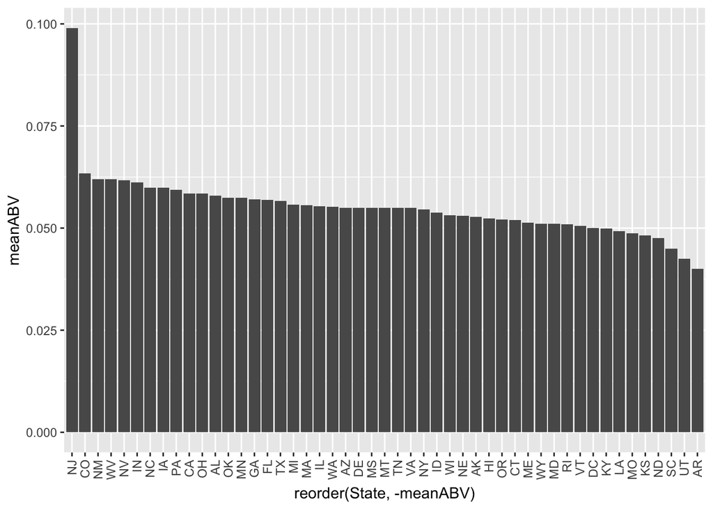

```r
#If you want to make an Ale here are the states you should market to
df = mergedBall %>% filter(group == "Ale") %>% group_by(State)%>% summarise(meanABV = mean(ABV)) %>% arrange(desc(meanABV))
ggplot(df, aes(x = reorder(State, -meanABV), y = meanABV)) + geom_bar(stat = "identity")+ theme(axis.text.x = element_text(angle = 90, vjust = 0.5, hjust=1))
```

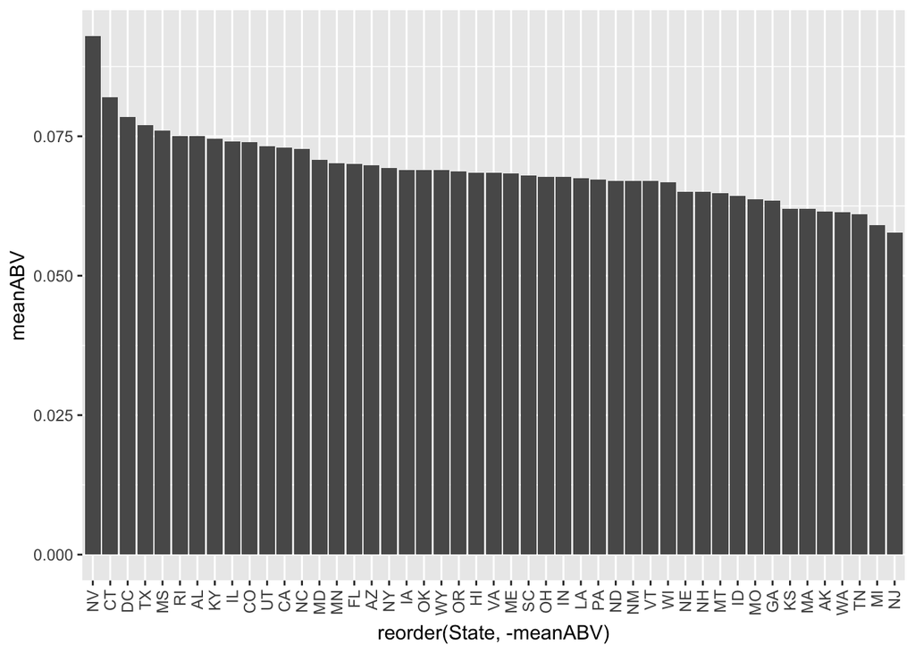

```r
#If you want to make an IPA here are the states you should market to
df = mergedBall %>% filter(group == "IPA") %>% group_by(State)%>% summarise(meanABV = mean(ABV)) %>% arrange(desc(meanABV))
ggplot(df, aes(x = reorder(State, -meanABV), y = meanABV)) + geom_bar(stat = "identity")+ theme(axis.text.x = element_text(angle = 90, vjust = 0.5, hjust=1))
```